# 4-2-3-trees slides

## 2-3 Trees

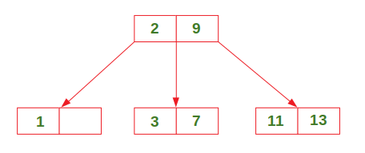

#### A 2-3 Tree..

- is a multi-way search tree that can have up to three children.
- provides fast operations that are easy to implement (similar to BST and AVL trees).
- gets its name from the number of keys and children each node can contain.

#### 2-3 Trees

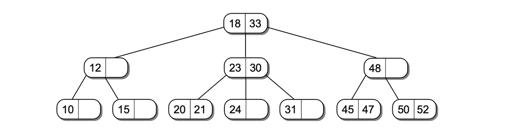

#### 2-3 Trees

- Are always balanced
- Every node has capacity for one or two keys (and their corresponding payload), which we term key one and key two.
- Every **internal** node has capacity for up to three children, which we term the left, middle, and right child.
- All leaf nodes are at the same level.
  - A **leaf** node may have at most 2 values.
- Every internal node must contain two or three children.
  - If the node has one key, it must contain two children;
  - if it has two keys, it must contain three children.

#### 2-3 Trees

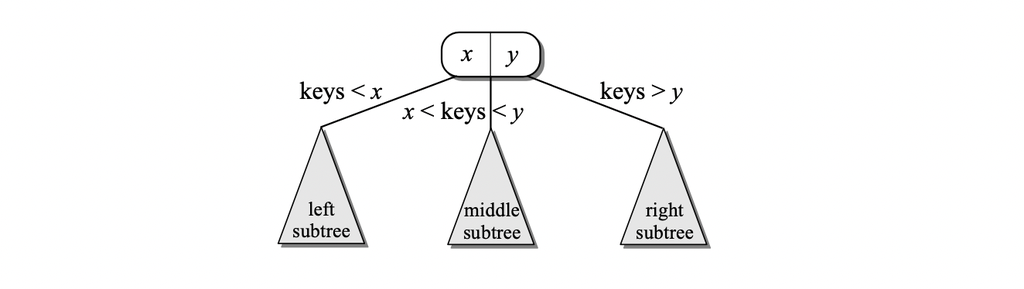

#### 2-3 Trees

- All keys less than the first key of node $V $ are stored in the left subtree of $V$.
- If the internal node has two children, all keys greater than the first key of node $V $ are stored in the middle subtree of $V $ .
- If the internal node has three children:
  1. All keys greater than the first key of node $V$ but less than the second key are stored in the middle subtree of $V$ ; and
  2. All keys greater than the second key are stored in the right subtree.

#### Search for 55

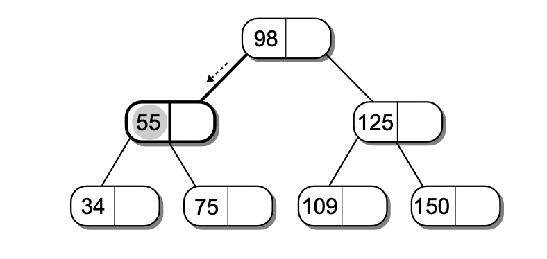

#### Search for 68

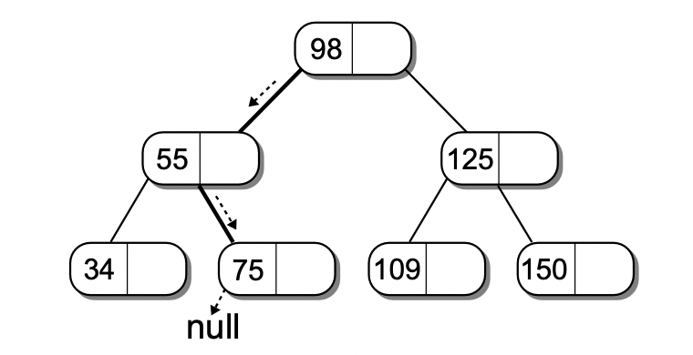

#### Search for 24, 32, 49, 19

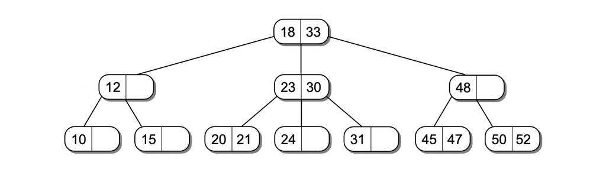

#### Insertion

##### Insert 84

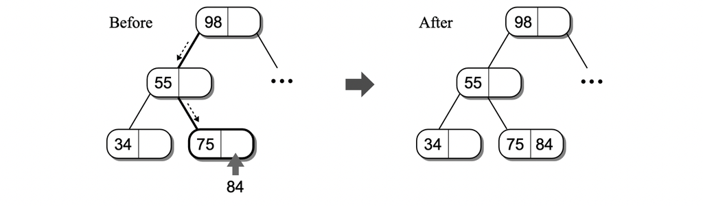

##### Space in the leaf node

#### Insertion

##### Insert 26

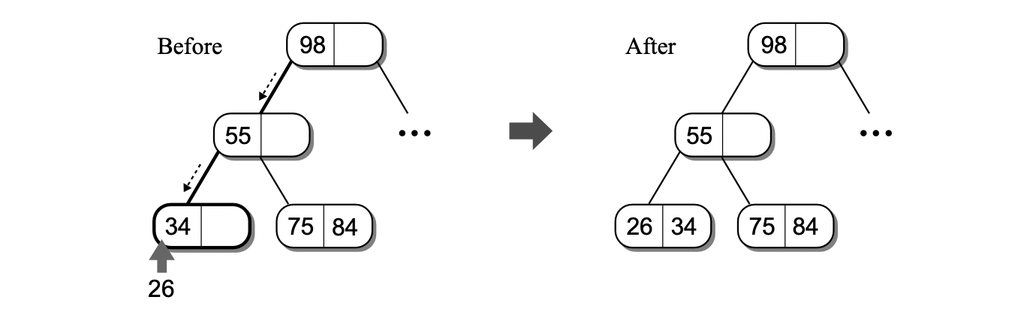

##### Space in the leaf node

### Insertion

##### Insert 80

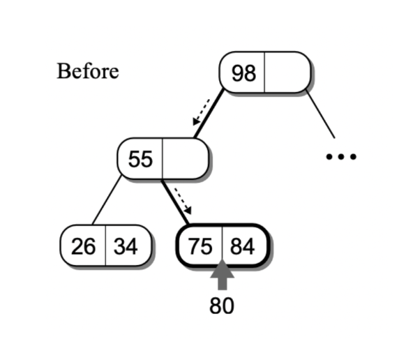

#### Insertion

##### Insert 80: How about this?

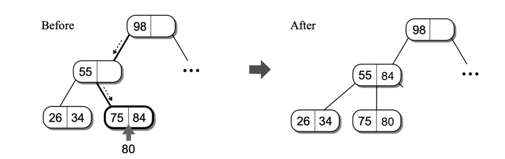

#### Insertion

##### Insert 80: Why not like so?

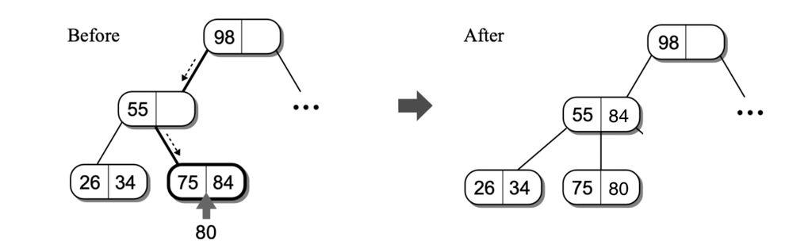

#### Insertion

##### Insert 80: Why not like so?

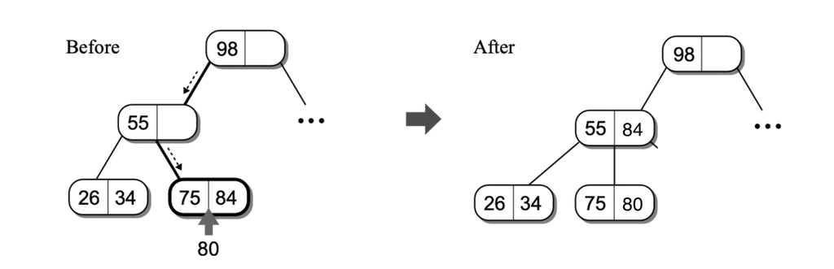

- Every internal node must contain two or three children.
  - If the node has one key, it must contain two children;
  - **If it has two keys, it must contain three children.**

#### Insertion

##### Insert 80: Or how about this?

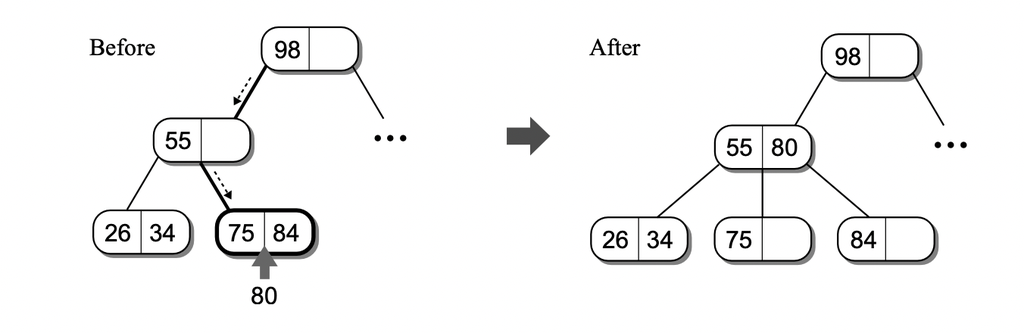

#### Insertions

#### Insert 80: Works!

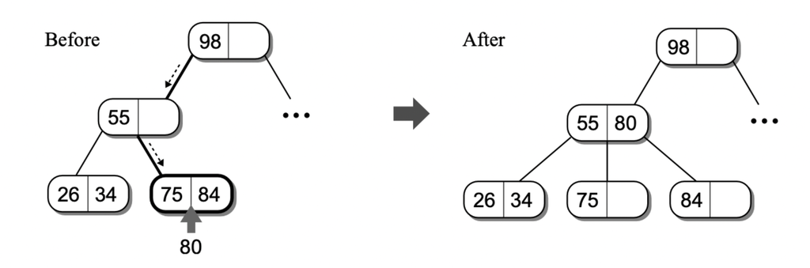

#### Insertions: Splitting

- First, a new node is created, then the new key is compared to the two keys (75 and 84) in the original node.
- The smallest among the three is inserted into the original node and the largest is inserted into the new node.
- The middle value is promoted to the parent along with a reference to the newly created node.
- The promoted key and reference are then inserted into the parent node.

#### Splitting a LEAF node into two nodes

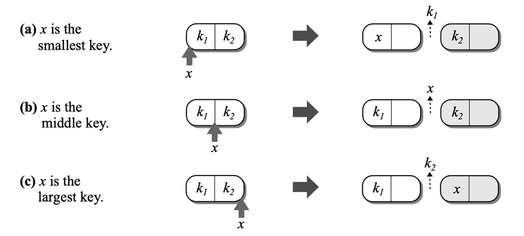

#### Splitting: Parent has 3 children

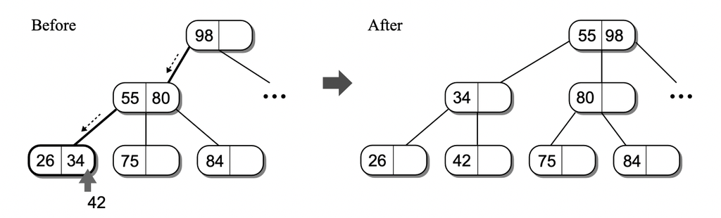

- When the parent node is split, a new parent node is created the two will become siblings.
- Two of the three keys, the two in the original parent, $p_1$ and $p_2$, and the promoted key, $k_p\ $, have to be distributed between the two parents and one has to be promoted to the grandparent.

#### Splitting the root node

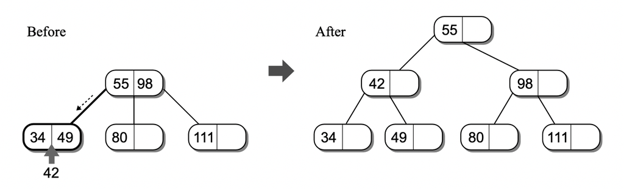

https://opendsa-server.cs.vt.edu/ODSA/Books/CS3/html/TwoThreeTree.html

#### 2-3 Trees

- A 2-3 tree is height balanced with all leaf nodes at the same level.
- In the worst case, all nodes in the 2-3 tree will contain a single key and all interior nodes will only have two children.
- This results in a height of $\it{log }$ $n$ for a tree of size $n$.
- Search time: $O(\log n)$.